# Exercise 2

Read data and look at its structure.

```r
wine <- read.csv("wine.csv", header=TRUE)
fix(wine)
str(wine)
```

```
'data.frame':   25 obs. of  7 variables:
 $ Year       : num  1952 1953 1955 1957 1958 ...
 $ Price      : num  7.5 8.04 7.69 6.98 6.78 ...
 $ WinterRain : num  600 690 502 420 582 485 763 830 697 608 ...
 $ AGST       : num  17.1 16.7 17.1 16.1 16.4 ...
 $ HarvestRain: num  160 80 130 110 187 187 290 38 52 155 ...
 $ Age        : num  31 30 28 26 25 24 23 22 21 20 ...
 $ FrancePop  : num  43184 43495 44218 45152 45654 ...
```

Summarize data.

```r
summary(wine)
```

```
      Year          Price         WinterRain         AGST
 Min.   :1952   Min.   :6.205   Min.   :376.0   Min.   :14.98
 1st Qu.:1960   1st Qu.:6.519   1st Qu.:536.0   1st Qu.:16.20
 Median :1966   Median :7.121   Median :600.0   Median :16.53
 Mean   :1966   Mean   :7.067   Mean   :605.3   Mean   :16.51
 3rd Qu.:1972   3rd Qu.:7.495   3rd Qu.:697.0   3rd Qu.:17.07
 Max.   :1978   Max.   :8.494   Max.   :830.0   Max.   :17.65
  HarvestRain         Age         FrancePop
 Min.   : 38.0   Min.   : 5.0   Min.   :43184
 1st Qu.: 89.0   1st Qu.:11.0   1st Qu.:46584
 Median :130.0   Median :17.0   Median :50255
 Mean   :148.6   Mean   :17.2   Mean   :49694
 3rd Qu.:187.0   3rd Qu.:23.0   3rd Qu.:52894
 Max.   :292.0   Max.   :31.0   Max.   :54602
```

One variable regression

Create model1 with Price and AGST.

```r
model1=lm(Price~AGST, data=wine)
summary(model1)
```

```
Call:
lm(formula = Price ~ AGST, data = wine)

Residuals:
     Min       1Q   Median       3Q      Max
-0.78450 -0.23882 -0.03727  0.38992  0.90318

Coefficients:
            Estimate Std. Error t value Pr(>|t|)
(Intercept)  -3.4178     2.4935  -1.371 0.183710
AGST          0.6351     0.1509   4.208 0.000335 ***
---
Signif. codes:  0 ‘***’ 0.001 ‘**’ 0.01 ‘*’ 0.05 ‘.’ 0.1 ‘ ’ 1

Residual standard error: 0.4993 on 23 degrees of freedom
Multiple R-squared:  0.435, Adjusted R-squared:  0.4105
F-statistic: 17.71 on 1 and 23 DF,  p-value: 0.000335
```

1. What does this model predict to be the price of a wine with AGST = 17.33C?

```r
model1_price = -3.4178+0.6351*17.33
model1_price
```

```
[1] 7.588483
```

The price would be 7.59.

2. In our data 17.33 o C was the average growing season temperature (AGST) of year 1961 (observation 8). What was the actual price that year?

```r
wine[8,]
```

|  | Year | Price | WinterRain | AGST | HarvestRain | Age | FrancePop |
| --- | --- | --- | --- | --- | --- | --- | --- |
| 8 | 1961 | 8.4937 | 830 | 17.3333 | 38 | 22 | 47128 |

The actual price was 8.49.

3. What is the residual 1961?

```r
model1_residual = 8.4937-7.588483
model1_residual
```

```
[1] 0.905217
```

4. Once you calculated the residual 1961, you can check it as follows. How close did you get?

```r
model1$residuals[8]
```

```
        8
0.9031812
```

The first two decimals are the same.

The expression: model1$residuals[8] referred to the 8th value of vector model1$residuals, which contains all the residuals of the model1. With [8] was specified the residual of observation number 8 which is the one of year 1961.

5. Calculate RSS with the residuals -vector (RSS=sum of squared residuals).

```r
model1_rss = sum((model1$residuals)^2)
model1_rss
```

```
[1] 5.734875
```

Multivariable regression

Now let’s add another independent variable, HarvestRain to our regression model. We’ll call it model2. Before starting to compare the models, let’s form one more, model3, with independent variables AGST, HarvestRain, WinterRain, Age and FrancePop.

```r
model2 = lm(Price~AGST+HarvestRain, data=wine)
model3 = lm(Price~AGST+HarvestRain+WinterRain+Age+FrancePop, data=wine)
```

6. Take again the observation number 8 - year 1961. Calculate with year 1961 values (observation 8) the predicted value of Price, given by model2.

```r
summary(model2)
```

```
Call:
lm(formula = Price ~ AGST + HarvestRain, data = wine)

Residuals:
     Min       1Q   Median       3Q      Max
-0.88321 -0.19600  0.06178  0.15379  0.59722

Coefficients:
            Estimate Std. Error t value Pr(>|t|)
(Intercept) -2.20265    1.85443  -1.188 0.247585
AGST         0.60262    0.11128   5.415 1.94e-05 ***
HarvestRain -0.00457    0.00101  -4.525 0.000167 ***
---
Signif. codes:  0 ‘***’ 0.001 ‘**’ 0.01 ‘*’ 0.05 ‘.’ 0.1 ‘ ’ 1

Residual standard error: 0.3674 on 22 degrees of freedom
Multiple R-squared:  0.7074,    Adjusted R-squared:  0.6808
F-statistic: 26.59 on 2 and 22 DF,  p-value: 1.347e-06
```

Let’s look at year 1961.

```r
wine[8,]
```

|  | Year | Price | WinterRain | AGST | HarvestRain | Age | FrancePop |
| --- | --- | --- | --- | --- | --- | --- | --- |
| 8 | 1961 | 8.4937 | 830 | 17.3333 | 38 | 22 | 47128 |

The predicted price with model2 for 1961 is

```r
model2_price = -2.20265 + 0.60262*17.3333 + (-0.00457)*38
model2_price
```

```
[1] 8.069083
```

The price for 1961 would be 8.07.

7. Calculate RSS for model2.

```r
model2_rss = sum((model2$residuals)^2)
model2_rss
```

```
[1] 2.970373
```

Calculate RSSs for model3.

```r
model3_rss = sum((model3$residuals)^2)
model3_rss
```

```
[1] 1.732113
```

Compare to RSS of model1: Model1 RSS was 5.734875, model2 RSS was 2.970373 and model3 RSS was 1.732113. The smaller the better, so model3 is best from this point of view.

Compare also R2, both multiple R2 and adjusted R2:

```r
summary(model3)
```

```
Call:
lm(formula = Price ~ AGST + HarvestRain + WinterRain + Age +
    FrancePop, data = wine)

Residuals:
     Min       1Q   Median       3Q      Max
-0.48179 -0.24662 -0.00726  0.22012  0.51987

Coefficients:
              Estimate Std. Error t value Pr(>|t|)
(Intercept) -4.504e-01  1.019e+01  -0.044 0.965202
AGST         6.012e-01  1.030e-01   5.836 1.27e-05 ***
HarvestRain -3.958e-03  8.751e-04  -4.523 0.000233 ***
WinterRain   1.043e-03  5.310e-04   1.963 0.064416 .
Age          5.847e-04  7.900e-02   0.007 0.994172
FrancePop   -4.953e-05  1.667e-04  -0.297 0.769578
---
Signif. codes:  0 ‘***’ 0.001 ‘**’ 0.01 ‘*’ 0.05 ‘.’ 0.1 ‘ ’ 1

Residual standard error: 0.3019 on 19 degrees of freedom
Multiple R-squared:  0.8294,    Adjusted R-squared:  0.7845
F-statistic: 18.47 on 5 and 19 DF,  p-value: 1.044e-06
```

Model1 values: Multiple R-squared: 0.435, Adjusted R-squared: 0.4105 Model2 values: Multiple R-squared: 0.7074, Adjusted R-squared: 0.6808 Model3 values: Multiple R-squared: 0.8294, Adjusted R-squared: 0.7845

Conclusion: Model3 is best as it is highest in terms of multiple R2 and adjusted R2.

Create model4 with independent variables AGST,HarvestRain, WinterRain and Age.

```r
model4 = lm(Price~AGST+HarvestRain+WinterRain+Age, data=wine)
summary(model4)
```

```
Call:
lm(formula = Price ~ AGST + HarvestRain + WinterRain + Age, data = wine)

Residuals:
     Min       1Q   Median       3Q      Max
-0.45470 -0.24273  0.00752  0.19773  0.53637

Coefficients:
              Estimate Std. Error t value Pr(>|t|)
(Intercept) -3.4299802  1.7658975  -1.942 0.066311 .
AGST         0.6072093  0.0987022   6.152  5.2e-06 ***
HarvestRain -0.0039715  0.0008538  -4.652 0.000154 ***
WinterRain   0.0010755  0.0005073   2.120 0.046694 *
Age          0.0239308  0.0080969   2.956 0.007819 **
---
Signif. codes:  0 ‘***’ 0.001 ‘**’ 0.01 ‘*’ 0.05 ‘.’ 0.1 ‘ ’ 1

Residual standard error: 0.295 on 20 degrees of freedom
Multiple R-squared:  0.8286,    Adjusted R-squared:  0.7943
F-statistic: 24.17 on 4 and 20 DF,  p-value: 2.036e-07
```

R2 values stayed about the same: Multiple R2 from 0.8294 to 0.8286 and Adjusted R2 from 0.7845 to 0.7943. Previously non-significant Age became significant in the model (0.001 < p < 0.01) and WinterRain’s significancy was increased from 0.05 < p < 0.1 to 0.01 < p < 0.05.

Correlation and multicollinearity

```r
cor(wine$Price,wine$AGST)
```

```
[1] 0.6595629
```

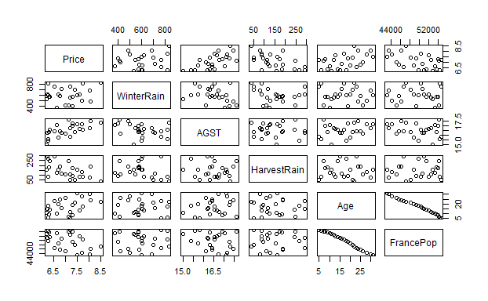

```r
plot(wine[,-1])
```

9. If you look at correlations between independent variables - are there other concerns about possible multicollinearity? In the model4, there are independent variables AGST, HarvestRain, WinterRain and Age. Let’s calculate correlations for each pair.

```r
cor(wine$AGST,wine$HarvestRain)
```

```
[1] -0.06449593
```

```r
cor(wine$AGST,wine$WinterRain)
```

```
[1] -0.3210906
```

Some correlation exists so let’s plot AGST and WinterRain.

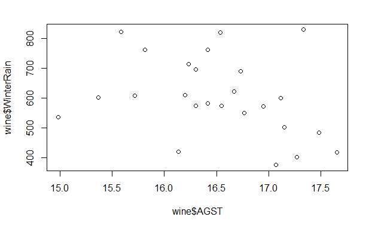

```r
plot(wine$AGST,wine$WinterRain)
```

No visible correlation.

```r
cor(wine$AGST,wine$Age)
```

```
[1] 0.2469159
```

Some correlation, let’s plot AGST and Age.

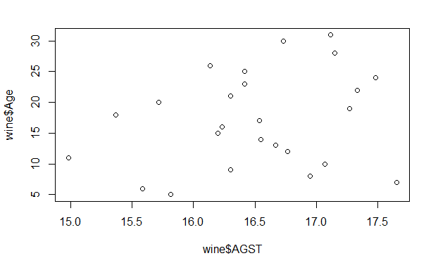

```r
plot(wine$AGST,wine$Age)
```

No visible correlation.

```r
cor(wine$HarvestRain,wine$WinterRain)
```

```
[1] -0.2754409
```

Some correlation, let’s plot HarvestRain and WinterRain

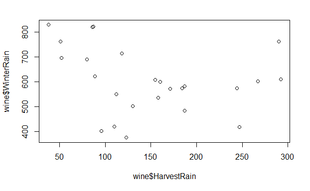

```r
plot(wine$HarvestRain,wine$WinterRain)
```

No visible correlation.

```r
cor(wine$HarvestRain,wine$Age)
```

```
[1] -0.02800907
```

```r
cor(wine$WinterRain,wine$Age)
```

```
[1] -0.01697002
```

Conclusion: No visible or thus remarkable collinearity in model4.

Read in wine_test.csv

```r
wine_test <- read.csv("wine_test.csv", header=TRUE)
str(wine_test)
```

```
'data.frame':   2 obs. of  7 variables:
 $ Year       : int  1979 1980
 $ Price      : num  6.95 6.5
 $ WinterRain : int  717 578
 $ AGST       : num  16.2 16
 $ HarvestRain: int  122 74
 $ Age        : int  4 3
 $ FrancePop  : num  54836 55110
```

Compare test set with model4

```r
predictTest = predict(model4, newdata = wine_test)
predictTest
```

```
       1        2
6.768925 6.684910
```

10. Calculate RSS with actual values of Prices in the test data and the values predicted by model4.

```r
RSS
```

```
[1] 0.06926281
```

11. Calculate TSS.

```r
TSS
```

```
[1] 0.3369269
```

12. Calculate R2.

```r
R2
```

```
[1] 0.7944278
```